# SASMarkdown

```r
colorize <- function(x, color) {
  if (knitr::is_latex_output()) {
    sprintf("\\textcolor{%s}{%s}", color, x)
  } else if (knitr::is_html_output()) {
    sprintf("<span style='color: %s;'>%s</span>", color,
      x)
  } else x
}

knitr::opts_chunk$set(cache.path = "cache/",
                      fig.path = "figures/")
```

# In a first code chunk, set up your SAS engine configuration.

This depends on your operating system, the version of SAS, and whether or not you have SAS installed in the default location. This example catches Windows SAS for me. In Macbook you just need to find the location of sas.exe and save the directory.

SASmarkdown has a very short memory, it could not save the previous code chunks in memory if you are using Rmarkdown editing anything. It only works when knitr works. If you want to use SAS but make PDF or DOC files If you want to knit to PDF or DOC, you should change the engine to engine=‘sas’. This will NOT use ODS output from SAS.

```r
# install.packages("SASmarkdown")
require(SASmarkdown)

# set up the options so that knit knows where you SAS executable is
# set the linesize to be easily readable on letter size paper, portrait
# and set the knir options using opts_chunk$set().

if (file.exists("C:/Program Files/SASHome/SASFoundation/9.4/sas.exe")) {
  saspath <- "C:/Program Files/SASHome/SASFoundation/9.4/sas.exe"
} else {
  saspath <- "sas"
}
sas_enginesetup(sashtml=sashtml)
sasopts <- "-nosplash -linesize 75"


knitr::opts_chunk$set(engine="sashtml", engine.path=saspath,
        engine.opts=sasopts, comment=NA)

# run these commands to convince yourself that
# within this knitr session the engine changed.
knitr::opts_chunk$get()$engine
```

```
## [1] "sashtml"
```

```r
knitr::opts_chunk$get()$engine.path
```

```
## [1] "C:/Program Files/SASHome/SASFoundation/9.4/sas.exe"
```

```r
knitr::opts_chunk$get()$engine.opts
```

```
## [1] "-nosplash -linesize 75"
```

# Example 1

use the sashlep.class data.

```sas
/* SAS code for exmple1, we are in SAS now so every comment has to change */
proc means data=sashelp.class (keep = age);
run;
```

```
                            The MEANS Procedure

                         Analysis Variable : Age

     N            Mean         Std Dev         Minimum         Maximum
    ------------------------------------------------------------------
    19      13.3157895       1.4926722      11.0000000      16.0000000
    ------------------------------------------------------------------
```

# Example 2

```
6          ods graphics off;
7          proc corr data=sashelp.class nosimple plots=matrix;
8          run;

WARNING: You must enable ODS graphics before requesting plots.
NOTE: PROCEDURE CORR used (Total process time):
      real time           0.10 seconds
      cpu time            0.03 seconds
```

| 3 Variables: | Age Height Weight |
| --- | --- |

| Pearson Correlation Coefficients, N = 19 Prob > \|r\| under H0: Rho=0 | Pearson Correlation Coefficients, N = 19 Prob > \|r\| under H0: Rho=0 Age | Pearson Correlation Coefficients, N = 19 Prob > \|r\| under H0: Rho=0 Height | Pearson Correlation Coefficients, N = 19 Prob > \|r\| under H0: Rho=0 Weight |
| --- | --- | --- | --- |
| Age | 1.00000 | 0.81143 <.0001 | 0.74089 0.0003 |
| Height | 0.81143 <.0001 | 1.00000 | 0.87779 <.0001 |
| Weight | 0.74089 0.0003 | 0.87779 <.0001 | 1.00000 |

```
proc corr data=sashelp.class nosimple plots=matrix;
run;
```

| 3 Variables: | Age Height Weight |
| --- | --- |

| Pearson Correlation Coefficients, N = 19 Prob > \|r\| under H0: Rho=0 | Pearson Correlation Coefficients, N = 19 Prob > \|r\| under H0: Rho=0 Age | Pearson Correlation Coefficients, N = 19 Prob > \|r\| under H0: Rho=0 Height | Pearson Correlation Coefficients, N = 19 Prob > \|r\| under H0: Rho=0 Weight |
| --- | --- | --- | --- |
| Age | 1.00000 | 0.81143 <.0001 | 0.74089 0.0003 |
| Height | 0.81143 <.0001 | 1.00000 | 0.87779 <.0001 |
| Weight | 0.74089 0.0003 | 0.87779 <.0001 | 1.00000 |

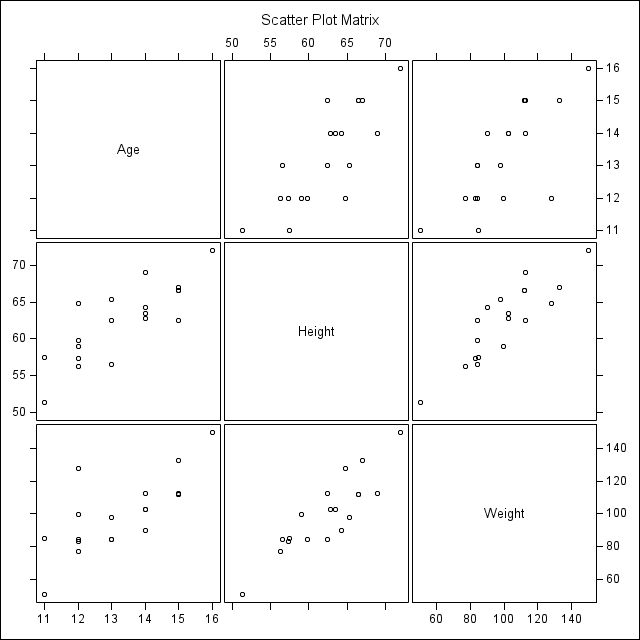

For this section the code must include the “collectcode = TRUE”

```
data class;
    set sashelp.class;
    keep age;
    run;
```

Without collectcode to link the code chunks, a later chunk that referenced the data in the WORK library would produce an error, but this now works. (No special option is needed for this later step.)

```
proc means data=class;
run;
```

| Analysis Variable : Age N | Analysis Variable : Age Mean | Analysis Variable : Age Std Dev | Analysis Variable : Age Minimum | Analysis Variable : Age Maximum |
| --- | --- | --- | --- | --- |
| 19 | 13.3157895 | 1.4926722 | 11.0000000 | 16.0000000 |